# Module 40

#### Hemi-module gene counts:

394 probesets in hemi-module A.  
128 probesets in hemi-module B.  
Note: While the mapping of probesets to genes is usually one-to-one, some genes are targeted by multiple probesets, some probesets target multiple genes, and some probesets do not target any genes (i.e., the region of the genome they match is no longer considered genic).

#### Contrast SVE:

Signed variance explained (SVE) provides an indication of how similar a set of fold changes are to a gene module’s weight vector. An SVE value of 0.3, for example, indicates that 30% of the variance explained by the entire module set is accounted for by the module in question. Shown here are the SVE values for this module across a compendium of fold changes (contrasts). Extreme SVE values (e.g., > 0.05) indicate that those contrasts specifically induce (orange dots) or specifically repress (blue dots) this module. Examining the experimental conditions being compared in such contrasts (see tables below the figure) may provide insight into the gene module’s function.

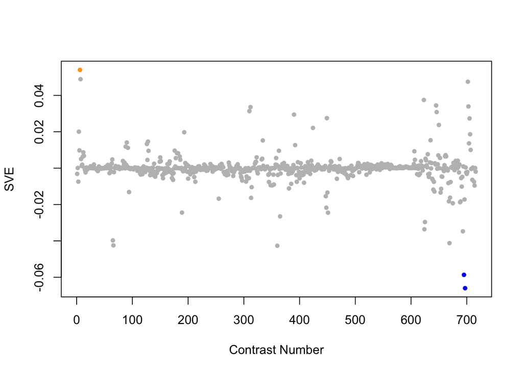

Positive SVE Contrasts:

|  | Contrast.Num | SVE | GEO.GSE | Cond.1 | Cond.2 | Mutation |
| --- | --- | --- | --- | --- | --- | --- |
| GSE9897B.s3t1.vs.s0t1 | 6 | 0.05 | GSE9897 | Complex I RNAi Mutant 3 | Wildtype (control for RNAi) | C34B2.8 |
| GSE9897B.s4t1.vs.s0t1 | 7 | 0.05 | GSE9897 | Complex I RNAi Mutant 4 | Wildtype (control for RNAi) | Y56A3A.19 |
| GSE11055.s1t2.vs.s1t1 | 702 | 0.05 | GSE11055 | L1 larvae 0 hr after hatching in the presence of food | embryo 2 hr before hatching |  |
| GSE20053.s1t1.vs.s0t1 | 623 | 0.04 | GSE20053 | C. elegans N2_Y. pestis KIM5_24h_Sample A | C. elegans N2_E. coli OP50_24h_Sample A |  |
| GSE16915.s2t1.vs.s3t1 | 645 | 0.03 | GSE16915 | positive control (heat shock) | bio-electrosprayed sample |  |

Negative SVE Contrasts:

|  | Contrast.Num | SVE | GEO.GSE | Cond.1 | Cond.2 | Mutation |
| --- | --- | --- | --- | --- | --- | --- |
| GSE11055.s1t8.vs.s2t8 | 697 | -0.07 | GSE11055 | L2 larvae 24 hr after hatching in the presence of food | L1 larvae 24 hr after hatching in the absence of food |  |
| GSE11055.s1t7.vs.s4t7 | 695 | -0.06 | GSE11055 | L1-L2 larvae 15 hr after hatching in the presence of food | L1 larvae fed for 12 hr after hatching and then starved for 3 hr |  |
| GSE37432.s1t1.vs.s0t1 | 360 | -0.04 | GSE37432 | piwi n4357 n4358 rep1 | N2 rep1 | prg-1;prg-2 |
| GSE8659.s3t1.vs.s1t1 | 66 | -0.04 | GSE8659 | strain NL 2099 replicate 2 | N2 replicate 1 | rrf-3 |
| GSE15016.s3t1.vs.s0t1 | 669 | -0.04 | GSE15016 | young adult_24hr DEHP exposure_rep1 | young adult_not exposured_rep1 |  |

$~$

#### Contrast SVE, Up-Regulated Genes Only:

Calculating SVE for up-regulated and down-regulated genes separately may be more informative in many cases than projecting the up- and down- gene sets together. This is due to the fact that the weight distribution of many modules is highly skewed, indicating that only one of the hemi-modules may be biologically meaningful (i.e., a set of genes are strongly correlated by only a few genes (or none) are strongly anti-correlated to that set.)

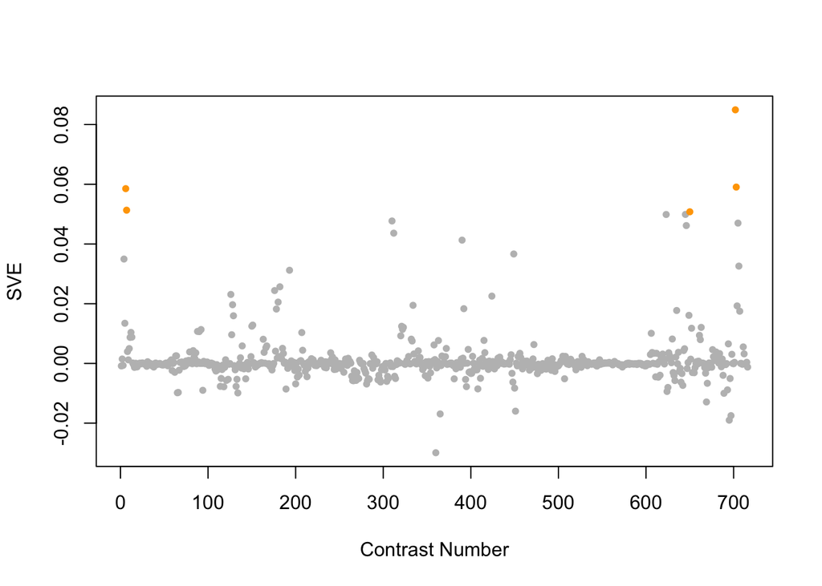

Positive SVE Contrasts:

|  | Contrast.Num | SVE | GEO.GSE | Cond.1 | Cond.2 | Mutation |
| --- | --- | --- | --- | --- | --- | --- |
| GSE11055.s1t2.vs.s1t1 | 702 | 0.08 | GSE11055 | L1 larvae 0 hr after hatching in the presence of food | embryo 2 hr before hatching |  |
| GSE11055.s1t3.vs.s1t1 | 703 | 0.06 | GSE11055 | L1 larvae 1 hr after hatching in the presence of food | embryo 2 hr before hatching |  |
| GSE9897B.s3t1.vs.s0t1 | 6 | 0.06 | GSE9897 | Complex I RNAi Mutant 3 | Wildtype (control for RNAi) | C34B2.8 |
| GSE9897B.s4t1.vs.s0t1 | 7 | 0.05 | GSE9897 | Complex I RNAi Mutant 4 | Wildtype (control for RNAi) | Y56A3A.19 |
| GSE16405.s3t1.vs.s1t1 | 650 | 0.05 | GSE16405 | nth-1;xpa-1_1 | N2_1 | nth-1;xpa-1 |

Negative SVE Contrasts:

|  | Contrast.Num | SVE | GEO.GSE | Cond.1 | Cond.2 | Mutation |
| --- | --- | --- | --- | --- | --- | --- |
| GSE37432.s1t1.vs.s0t1 | 360 | -0.03 | GSE37432 | piwi n4357 n4358 rep1 | N2 rep1 | prg-1;prg-2 |
| GSE11055.s1t7.vs.s4t7 | 695 | -0.02 | GSE11055 | L1-L2 larvae 15 hr after hatching in the presence of food | L1 larvae fed for 12 hr after hatching and then starved for 3 hr |  |
| GSE11055.s1t8.vs.s2t8 | 697 | -0.02 | GSE11055 | L2 larvae 24 hr after hatching in the presence of food | L1 larvae 24 hr after hatching in the absence of food |  |
| GSE36358.s3t1.vs.s0t1 | 365 | -0.02 | GSE36358 | Hyper Gravity | Ground Control (Tsukuba space center) |  |
| GSE25633.s1t1.vs.s3t1 | 451 | -0.02 | GSE25633 | WT#1 | daf-12#1 | daf-12 |

$~$

#### Contrast SVE, Down-Regulated Genes Only:

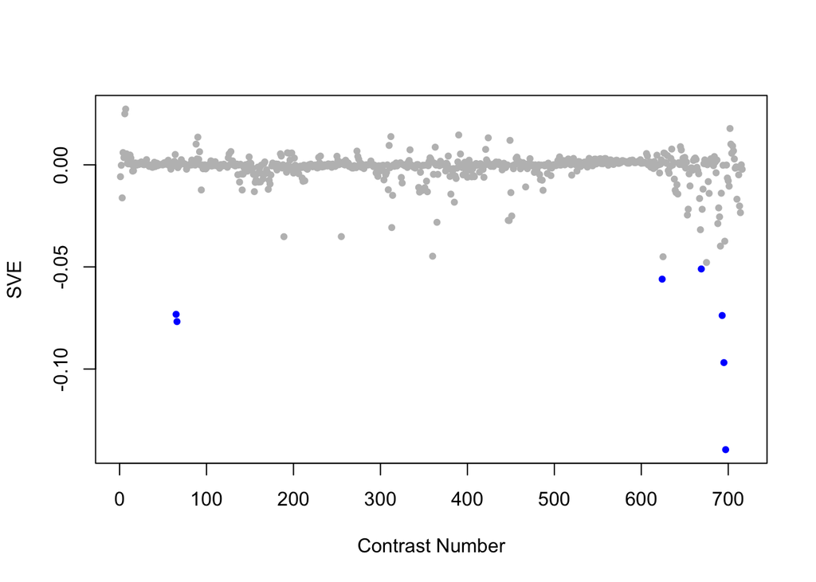

Positive SVE Contrasts:

|  | Contrast.Num | SVE | GEO.GSE | Cond.1 | Cond.2 | Mutation |
| --- | --- | --- | --- | --- | --- | --- |
| GSE9897B.s4t1.vs.s0t1 | 7 | 0.03 | GSE9897 | Complex I RNAi Mutant 4 | Wildtype (control for RNAi) | Y56A3A.19 |
| GSE9897B.s3t1.vs.s0t1 | 6 | 0.02 | GSE9897 | Complex I RNAi Mutant 3 | Wildtype (control for RNAi) | C34B2.8 |
| GSE11055.s1t2.vs.s1t1 | 702 | 0.02 | GSE11055 | L1 larvae 0 hr after hatching in the presence of food | embryo 2 hr before hatching |  |
| GSE32521.s1t1.vs.s0t1 | 390 | 0.01 | GSE32521 | Au-NP Replicate1 | Control Replicate1 |  |
| GSE41056.s1t2.vs.s1t1 | 312 | 0.01 | GSE41056 | JU1580_inf_1 | JU1580_1 |  |

Negative SVE Contrasts:

|  | Contrast.Num | SVE | GEO.GSE | Cond.1 | Cond.2 | Mutation |
| --- | --- | --- | --- | --- | --- | --- |
| GSE11055.s1t8.vs.s2t8 | 697 | -0.14 | GSE11055 | L2 larvae 24 hr after hatching in the presence of food | L1 larvae 24 hr after hatching in the absence of food |  |
| GSE11055.s1t7.vs.s4t7 | 695 | -0.10 | GSE11055 | L1-L2 larvae 15 hr after hatching in the presence of food | L1 larvae fed for 12 hr after hatching and then starved for 3 hr |  |
| GSE8659.s3t1.vs.s1t1 | 66 | -0.08 | GSE8659 | strain NL 2099 replicate 2 | N2 replicate 1 | rrf-3 |
| GSE11055.s1t7.vs.s2t7 | 693 | -0.07 | GSE11055 | L1-L2 larvae 15 hr after hatching in the presence of food | L1 larvae 15 hr after hatching in the absence of food |  |
| GSE8659.s2t1.vs.s1t1 | 65 | -0.07 | GSE8659 | strain GR1373 replicate 1 | N2 replicate 1 | eri-1 |
| GSE19972.s1t1.vs.s0t1 | 624 | -0.06 | GSE19972 | transgenic aex-3::his-SUMO-1 JS62_1 | control wild type N2_1 |  |
| GSE15016.s3t1.vs.s0t1 | 669 | -0.05 | GSE15016 | young adult_24hr DEHP exposure_rep1 | young adult_not exposured_rep1 |  |

$~$

$~$

#### GO Term Enrichment:

This analysis tests each hemi-module for enrichment of specific GO terms. Only gene-level annotations (e.g., as would be found on the gene’s page in Wormbase) are tested - the hierarchical structure of the GO ontology is not taken into account.

*Note: At least the top two most enriched terms from each GO domain (BP/MF/CC) are shown, even when not statistically significant.*

##### Enriched GO terms: Hemi-module A

| ID | GO.Term | GO Domain | Raw p-value | Adj p-value |
| --- | --- | --- | --- | --- |
| [GO_0006811](http://amigo.geneontology.org/amigo/term/GO:0006811) | ion transport | BP | 3.63e-14 | 1.32e-10 |
| [GO_0007638](http://amigo.geneontology.org/amigo/term/GO:0007638) | mechanosensory behavior | BP | 5.78e-12 | 1.05e-08 |
| [GO_0050976](http://amigo.geneontology.org/amigo/term/GO:0050976) | detection of mechanical stimulus involved in sensory perception of touch | BP | 1.90e-11 | 2.31e-08 |
| [GO_1905789](http://amigo.geneontology.org/amigo/term/GO:1905789) | positive regulation of detection of mechanical stimulus involved in sensory perception of touch | BP | 1.83e-08 | 1.34e-05 |
| [GO_1905792](http://amigo.geneontology.org/amigo/term/GO:1905792) | positive regulation of mechanosensory behavior | BP | 1.83e-08 | 1.34e-05 |
| [GO_0009612](http://amigo.geneontology.org/amigo/term/GO:0009612) | response to mechanical stimulus | BP | 5.13e-08 | 3.04e-05 |
| [GO_0007218](http://amigo.geneontology.org/amigo/term/GO:0007218) | neuropeptide signaling pathway | BP | 5.84e-08 | 3.04e-05 |
| [GO_0071805](http://amigo.geneontology.org/amigo/term/GO:0071805) | potassium ion transmembrane transport | BP | 1.45e-07 | 6.62e-05 |
| [GO_0034220](http://amigo.geneontology.org/amigo/term/GO:0034220) | ion transmembrane transport | BP | 2.63e-06 | 1.00e-03 |
| [GO_0007165](http://amigo.geneontology.org/amigo/term/GO:0007165) | signal transduction | BP | 2.74e-06 | 1.00e-03 |
| [GO_0030322](http://amigo.geneontology.org/amigo/term/GO:0030322) | stabilization of membrane potential | BP | 5.32e-06 | 1.76e-03 |
| [GO_0045138](http://amigo.geneontology.org/amigo/term/GO:0045138) | nematode male tail tip morphogenesis | BP | 6.24e-06 | 1.89e-03 |
| [GO_0006548](http://amigo.geneontology.org/amigo/term/GO:0006548) | histidine catabolic process | BP | 9.86e-06 | 2.57e-03 |
| [GO_0019556](http://amigo.geneontology.org/amigo/term/GO:0019556) | histidine catabolic process to glutamate and formamide | BP | 9.86e-06 | 2.57e-03 |
| [GO_1902476](http://amigo.geneontology.org/amigo/term/GO:1902476) | chloride transmembrane transport | BP | 1.22e-05 | 2.97e-03 |
| [GO_0050877](http://amigo.geneontology.org/amigo/term/GO:0050877) | nervous system process | BP | 2.05e-05 | 4.66e-03 |
| [GO_0042391](http://amigo.geneontology.org/amigo/term/GO:0042391) | regulation of membrane potential | BP | 2.75e-05 | 5.88e-03 |
| [GO_0007268](http://amigo.geneontology.org/amigo/term/GO:0007268) | chemical synaptic transmission | BP | 5.44e-05 | 1.10e-02 |
| [GO_0009952](http://amigo.geneontology.org/amigo/term/GO:0009952) | anterior/posterior pattern specification | BP | 9.06e-05 | 1.74e-02 |
| [GO_0097402](http://amigo.geneontology.org/amigo/term/GO:0097402) | neuroblast migration | BP | 1.77e-04 | 3.23e-02 |
| [GO_1904731](http://amigo.geneontology.org/amigo/term/GO:1904731) | positive regulation of intestinal lipid absorption | BP | 3.24e-04 | 5.61e-02 |
| [GO_0006547](http://amigo.geneontology.org/amigo/term/GO:0006547) | histidine metabolic process | BP | 4.62e-04 | 6.88e-02 |
| [GO_0019557](http://amigo.geneontology.org/amigo/term/GO:0019557) | histidine catabolic process to glutamate and formate | BP | 4.62e-04 | 6.88e-02 |
| [GO_0006813](http://amigo.geneontology.org/amigo/term/GO:0006813) | potassium ion transport | BP | 4.81e-04 | 6.88e-02 |
| [GO_0001966](http://amigo.geneontology.org/amigo/term/GO:0001966) | thigmotaxis | BP | 5.10e-04 | 6.88e-02 |
| [GO_0006801](http://amigo.geneontology.org/amigo/term/GO:0006801) | superoxide metabolic process | BP | 5.10e-04 | 6.88e-02 |
| [GO_1904936](http://amigo.geneontology.org/amigo/term/GO:1904936) | interneuron migration | BP | 5.10e-04 | 6.88e-02 |
| [GO_0010877](http://amigo.geneontology.org/amigo/term/GO:0010877) | lipid transport involved in lipid storage | BP | 7.52e-04 | 9.73e-02 |
| [GO_0007626](http://amigo.geneontology.org/amigo/term/GO:0007626) | locomotory behavior | BP | 7.74e-04 | 9.73e-02 |
| [GO_0005216](http://amigo.geneontology.org/amigo/term/GO:0005216) | ion channel activity | MF | 1.88e-10 | 3.84e-07 |
| [GO_0005267](http://amigo.geneontology.org/amigo/term/GO:0005267) | potassium channel activity | MF | 6.00e-08 | 6.13e-05 |
| [GO_0022841](http://amigo.geneontology.org/amigo/term/GO:0022841) | potassium ion leak channel activity | MF | 5.32e-06 | 3.62e-03 |
| [GO_0005254](http://amigo.geneontology.org/amigo/term/GO:0005254) | chloride channel activity | MF | 7.41e-06 | 3.78e-03 |
| [GO_0005230](http://amigo.geneontology.org/amigo/term/GO:0005230) | extracellular ligand-gated ion channel activity | MF | 2.26e-05 | 9.24e-03 |
| [GO_0005524](http://amigo.geneontology.org/amigo/term/GO:0005524) | ATP binding | MF | 3.54e-05 | 1.21e-02 |
| [GO_0004930](http://amigo.geneontology.org/amigo/term/GO:0004930) | G protein-coupled receptor activity | MF | 1.43e-04 | 3.82e-02 |
| [GO_0003723](http://amigo.geneontology.org/amigo/term/GO:0003723) | RNA binding | MF | 1.49e-04 | 3.82e-02 |
| [GO_0004888](http://amigo.geneontology.org/amigo/term/GO:0004888) | transmembrane signaling receptor activity | MF | 3.09e-04 | 7.01e-02 |
| [GO_0015280](http://amigo.geneontology.org/amigo/term/GO:0015280) | ligand-gated sodium channel activity | MF | 4.62e-04 | 9.43e-02 |
| [GO_0005887](http://amigo.geneontology.org/amigo/term/GO:0005887) | integral component of plasma membrane | CC | 1.73e-08 | 1.60e-05 |
| [GO_0043005](http://amigo.geneontology.org/amigo/term/GO:0043005) | neuron projection | CC | 9.11e-07 | 4.23e-04 |
| [GO_0005886](http://amigo.geneontology.org/amigo/term/GO:0005886) | plasma membrane | CC | 2.09e-06 | 6.47e-04 |
| [GO_0005737](http://amigo.geneontology.org/amigo/term/GO:0005737) | cytoplasm | CC | 1.36e-05 | 3.16e-03 |
| [GO_0016021](http://amigo.geneontology.org/amigo/term/GO:0016021) | integral component of membrane | CC | 7.31e-05 | 1.36e-02 |
| [GO_0016020](http://amigo.geneontology.org/amigo/term/GO:0016020) | membrane | CC | 1.10e-04 | 1.70e-02 |
| [GO_0008076](http://amigo.geneontology.org/amigo/term/GO:0008076) | voltage-gated potassium channel complex | CC | 1.77e-04 | 2.35e-02 |
| [GO_0005739](http://amigo.geneontology.org/amigo/term/GO:0005739) | mitochondrion | CC | 2.93e-04 | 3.40e-02 |
| [GO_0034707](http://amigo.geneontology.org/amigo/term/GO:0034707) | chloride channel complex | CC | 6.44e-04 | 6.64e-02 |

##### Enriched GO terms: Hemi-module B

| ID | GO.Term | GO Domain | Raw p-value | Adj p-value |
| --- | --- | --- | --- | --- |
| [GO_0007218](http://amigo.geneontology.org/amigo/term/GO:0007218) | neuropeptide signaling pathway | BP | 1.15e-04 | 3.68e-01 |
| [GO_0007411](http://amigo.geneontology.org/amigo/term/GO:0007411) | axon guidance | BP | 2.54e-04 | 3.68e-01 |
| [GO_0004867](http://amigo.geneontology.org/amigo/term/GO:0004867) | serine-type endopeptidase inhibitor activity | MF | 1.40e-04 | 1.51e-01 |
| [GO_0000981](http://amigo.geneontology.org/amigo/term/GO:0000981) | DNA-binding transcription factor activity, RNA polymerase II-specific | MF | 1.48e-04 | 1.51e-01 |
| [GO_0043005](http://amigo.geneontology.org/amigo/term/GO:0043005) | neuron projection | CC | 1.52e-03 | 9.97e-01 |
| [GO_0043235](http://amigo.geneontology.org/amigo/term/GO:0043235) | receptor complex | CC | 2.97e-03 | 9.97e-01 |

$~$

$~$

#### Tissue Enrichment:

This analysis tests each hemi-module for enrichment of genes associated with anatomy terms. Negative enrichment scores indicate fewer hemi-module genes than expected by random chance were associated with the anatomy term in question.

##### Enriched tissues: Hemi-module A

| ID | Anatomy.Term | Definition | Raw p-value | Adj p-value |
| --- | --- | --- | --- | --- |
| [WBbt_0004103](https://wormbase.org/species/all/anatomy_term/WBbt:0004103) | PLMR | Posterior lateral microtubule cell, touch receptor | 2.70e-12 | 3.92e-09 |
| [WBbt_0004104](https://wormbase.org/species/all/anatomy_term/WBbt:0004104) | PLML | Posterior lateral microtubule cell, touch receptor | 3.22e-12 | 3.92e-09 |
| [WBbt_0003953](https://wormbase.org/species/all/anatomy_term/WBbt:0003953) | ALMR | Anterior lateral microtubule cell, touch receptor | 6.29e-11 | 4.53e-08 |
| [WBbt_0003954](https://wormbase.org/species/all/anatomy_term/WBbt:0003954) | ALML | Anterior lateral microtubule cell, touch receptor | 7.45e-11 | 4.53e-08 |
| [WBbt_0004799](https://wormbase.org/species/all/anatomy_term/WBbt:0004799) | F cell | Rectal cell, blast cell in male | 2.73e-10 | 1.33e-07 |
| [WBbt_0003832](https://wormbase.org/species/all/anatomy_term/WBbt:0003832) | AVM | Neuron class of one sensory neuron, anterior ventral microtubule cell, touch receptor. | 3.80e-10 | 1.54e-07 |
| [WBbt_0004086](https://wormbase.org/species/all/anatomy_term/WBbt:0004086) | PVM | Neuron class of one neuron, posterior ventral microtuble cell, touch receptor. | 3.28e-09 | 1.14e-06 |
| [WBbt_0004942](https://wormbase.org/species/all/anatomy_term/WBbt:0004942) | U cell | Rectal cell, postembryonic blast cell in male | 9.80e-08 | 2.98e-05 |
| [WBbt_0004499](https://wormbase.org/species/all/anatomy_term/WBbt:0004499) | K cell | Rectal cell, postembryonic blast cell | 1.05e-06 | 2.64e-04 |
| [WBbt_0003825](https://wormbase.org/species/all/anatomy_term/WBbt:0003825) | B cell | Rectal cell, postembryonic blast cell in male | 1.09e-06 | 2.64e-04 |
| [WBbt_0004072](https://wormbase.org/species/all/anatomy_term/WBbt:0004072) | PVR | Neuron class of one asymmetric interneuron, projects along ventral cord to ring, sends process into tail spike. | 7.77e-06 | 1.72e-03 |
| [WBbt_0004578](https://wormbase.org/species/all/anatomy_term/WBbt:0004578) | Y cell | Rectal cell at hatching, becomes PDA in hermaphrodite, postembryonic blast cell in male | 1.01e-05 | 2.04e-03 |
| [WBbt_0004797](https://wormbase.org/species/all/anatomy_term/WBbt:0004797) | FLPR | Neuron, ciliated ending in head, no supporting cells, associated with ILso | 1.24e-05 | 2.15e-03 |
| [WBbt_0004798](https://wormbase.org/species/all/anatomy_term/WBbt:0004798) | FLPL | Neuron, ciliated ending in head, no supporting cells, associated with ILso | 1.24e-05 | 2.15e-03 |
| [WBbt_0004066](https://wormbase.org/species/all/anatomy_term/WBbt:0004066) | PVWL | Interneuron, posterior ventral cord, few synapses. | 2.52e-05 | 3.62e-03 |
| [WBbt_0005659](https://wormbase.org/species/all/anatomy_term/WBbt:0005659) | PHBR | Phasmid neuron, probably chemosensory | 2.54e-05 | 3.62e-03 |
| [WBbt_0005237](https://wormbase.org/species/all/anatomy_term/WBbt:0005237) | touch receptor neuron | neurons that sense body touch, have specialized microtubules in processes. | 2.68e-05 | 3.62e-03 |
| [WBbt_0004364](https://wormbase.org/species/all/anatomy_term/WBbt:0004364) | PHBL | Phasmid neurons, probably chemosensory | 2.75e-05 | 3.62e-03 |
| [WBbt_0004094](https://wormbase.org/species/all/anatomy_term/WBbt:0004094) | PVCL | Ventral cord interneuron, cell body in lumbar ganglion, synapses onto VB and DB motor neurons, formerly called delta. | 2.82e-05 | 3.62e-03 |
| [WBbt_0004092](https://wormbase.org/species/all/anatomy_term/WBbt:0004092) | PVCR | Ventral cord interneuron, cell body in lumbar ganglion, synapses onto VB and DB motor neurons, formerly called delta. | 3.29e-05 | 4.00e-03 |
| [WBbt_0004064](https://wormbase.org/species/all/anatomy_term/WBbt:0004064) | PVWR | Interneuron, posterior ventral cord, few synapses. | 3.59e-05 | 4.16e-03 |
| [WBbt_0004823](https://wormbase.org/species/all/anatomy_term/WBbt:0004823) | DVA | Neuron class of one ring interneuron, cell body in dorsorectal ganglion, has a large vesicle-filled process in ring. | 5.85e-05 | 6.47e-03 |
| [WBbt_0004088](https://wormbase.org/species/all/anatomy_term/WBbt:0004088) | PVDR | Neuron, lateral process adjacent to excretory canal | 1.10e-04 | 1.11e-02 |
| [WBbt_0004090](https://wormbase.org/species/all/anatomy_term/WBbt:0004090) | PVDL | Neuron, lateral process adjacent to excretory canal | 1.10e-04 | 1.11e-02 |
| [WBbt_0006986](https://wormbase.org/species/all/anatomy_term/WBbt:0006986) | B.p | cell, posterior daughter of B cell in male | 1.59e-04 | 1.55e-02 |
| [WBbt_0004821](https://wormbase.org/species/all/anatomy_term/WBbt:0004821) | DVC | Neuron class of one ring interneuron, cell body in dorsorectal ganglion. | 3.08e-04 | 2.81e-02 |
| [WBbt_0006985](https://wormbase.org/species/all/anatomy_term/WBbt:0006985) | B.a | cell, anterior daughter of B cell in male | 3.12e-04 | 2.81e-02 |
| [WBbt_0004378](https://wormbase.org/species/all/anatomy_term/WBbt:0004378) | hyp10 | Tail ventral hypodermis | 3.40e-04 | 2.96e-02 |
| [WBbt_0005796](https://wormbase.org/species/all/anatomy_term/WBbt:0005796) | intestinal muscle | intestinal muscle cell, attach to intestine and body wall anterior to anus | 3.77e-04 | 3.16e-02 |
| [WBbt_0004386](https://wormbase.org/species/all/anatomy_term/WBbt:0004386) | PDA | Neuron class of one motor neuron, process in dorsal cord, same as Y cell in hermaphrodite, Y.a in male. | 4.39e-04 | 3.56e-02 |
| [WBbt_0004365](https://wormbase.org/species/all/anatomy_term/WBbt:0004365) | PHAR | Phasmid neurons, probably chemosensory | 4.82e-04 | 3.66e-02 |
| [WBbt_0004366](https://wormbase.org/species/all/anatomy_term/WBbt:0004366) | PHAL | Phasmid neurons, probably chemosensory | 4.82e-04 | 3.66e-02 |
| [WBbt_0006888](https://wormbase.org/species/all/anatomy_term/WBbt:0006888) | P12.a | descendent cell of P12, anterior | 5.36e-04 | 3.88e-02 |
| [WBbt_0006998](https://wormbase.org/species/all/anatomy_term/WBbt:0006998) | TL.aa | cell, which is the anterior descendent of TL.a. | 6.54e-04 | 3.88e-02 |
| [WBbt_0007002](https://wormbase.org/species/all/anatomy_term/WBbt:0007002) | TR.aa | cell, which is the anterior descendent of TR.a. | 6.54e-04 | 3.88e-02 |
| [WBbt_0007012](https://wormbase.org/species/all/anatomy_term/WBbt:0007012) | TL.pp | cell, which is the posterior descendent of TL.p. | 6.54e-04 | 3.88e-02 |
| [WBbt_0007016](https://wormbase.org/species/all/anatomy_term/WBbt:0007016) | TR.pp | cell, which is the posterior descendent of TR.p. | 6.54e-04 | 3.88e-02 |
| [WBbt_0007215](https://wormbase.org/species/all/anatomy_term/WBbt:0007215) | P10.pa | post-embryonic cell of pedigree P10.pa | 6.54e-04 | 3.88e-02 |
| [WBbt_0007819](https://wormbase.org/species/all/anatomy_term/WBbt:0007819) | P11.pa | post-embryonic cell of pedigree P11.pa, only present in male animals. | 6.54e-04 | 3.88e-02 |
| [WBbt_0007820](https://wormbase.org/species/all/anatomy_term/WBbt:0007820) | P11.paa | post-embryonic cell of pedigree P11.paa, only present in male animals. | 6.54e-04 | 3.88e-02 |
| [WBbt_0007821](https://wormbase.org/species/all/anatomy_term/WBbt:0007821) | P11.pap | post-embryonic cell of pedigree P11.pap, only present in male animals. | 6.54e-04 | 3.88e-02 |
| [WBbt_0004944](https://wormbase.org/species/all/anatomy_term/WBbt:0004944) | TR | Tail seam hypodermal cell, postembryonic blast cell, functions as phasmid socket in L1 | 7.60e-04 | 4.40e-02 |
| [WBbt_0004380](https://wormbase.org/species/all/anatomy_term/WBbt:0004380) | hyp9 | Tail ventral hypodermis, 9th hypodermis cell | 9.48e-04 | 5.36e-02 |
| [WBbt_0004970](https://wormbase.org/species/all/anatomy_term/WBbt:0004970) | SMDVL | Ring motor neuron/interneuron, has a posteriorly direct ed process that runs sublaterally | 1.03e-03 | 5.68e-02 |
| [WBbt_0004409](https://wormbase.org/species/all/anatomy_term/WBbt:0004409) | P12 | Postembryonic blast cells for ventral cord motorneurons, ventral hypodermis, vulva, male preanal ganglion; ventral hypodermis in L1 | 1.15e-03 | 6.10e-02 |
| [WBbt_0004969](https://wormbase.org/species/all/anatomy_term/WBbt:0004969) | SMDVR | Ring motor neuron/interneuron, has a posteriorly direct ed process that runs sublaterally | 1.15e-03 | 6.10e-02 |
| [WBbt_0003811](https://wormbase.org/species/all/anatomy_term/WBbt:0003811) | BDUR | Neuron, process runs along excretory canal and into ring, unique darkly staining synaptic vesicles | 1.29e-03 | 6.54e-02 |
| [WBbt_0003812](https://wormbase.org/species/all/anatomy_term/WBbt:0003812) | BDUL | Neuron, process runs along excretory canal and into ring, unique darkly staining synaptic vesicles | 1.29e-03 | 6.54e-02 |
| [WBbt_0004497](https://wormbase.org/species/all/anatomy_term/WBbt:0004497) | K’ cell | Rectal cell | 1.74e-03 | 8.09e-02 |
| [WBbt_0003850](https://wormbase.org/species/all/anatomy_term/WBbt:0003850) | AVG | Neuron class of one ventral cord interneuron, few synapses. | 1.80e-03 | 8.09e-02 |
| [WBbt_0004372](https://wormbase.org/species/all/anatomy_term/WBbt:0004372) | hyp_hook | Hypodermis associated with hook sensillum of male, contains nucleus P11.ppp | 1.93e-03 | 8.09e-02 |
| [WBbt_0007000](https://wormbase.org/species/all/anatomy_term/WBbt:0007000) | TL.pa | cell, which is the anterior descendent of TL.p. | 1.93e-03 | 8.09e-02 |
| [WBbt_0007007](https://wormbase.org/species/all/anatomy_term/WBbt:0007007) | TR.pa | cell, which is the anterior descendent of TR.p. | 1.93e-03 | 8.09e-02 |
| [WBbt_0007010](https://wormbase.org/species/all/anatomy_term/WBbt:0007010) | TL.ap | cell, which is the posterior descendent of TL.a. | 1.93e-03 | 8.09e-02 |
| [WBbt_0007014](https://wormbase.org/species/all/anatomy_term/WBbt:0007014) | TR.ap | cell, which is the posterior descendent of TR.a. | 1.93e-03 | 8.09e-02 |
| [WBbt_0007221](https://wormbase.org/species/all/anatomy_term/WBbt:0007221) | P10.pp | post-embryonic cell of pedigree P10.pp | 1.93e-03 | 8.09e-02 |
| [WBbt_0007822](https://wormbase.org/species/all/anatomy_term/WBbt:0007822) | P11.pp | post-embryonic cell of pedigree P11.pp, only present in male animals. | 1.93e-03 | 8.09e-02 |
| [WBbt_0007823](https://wormbase.org/species/all/anatomy_term/WBbt:0007823) | P11.ppa | post-embryonic cell of pedigree P11.ppa, only present in male animals. | 1.93e-03 | 8.09e-02 |
| [WBbt_0004766](https://wormbase.org/species/all/anatomy_term/WBbt:0004766) | H1L | Seam hypodermal cell, postembryonic blast cell | 2.12e-03 | 8.44e-02 |
| [WBbt_0004890](https://wormbase.org/species/all/anatomy_term/WBbt:0004890) | V5L | Seam hypodermal cell, postembryonic blast cell | 2.12e-03 | 8.44e-02 |
| [WBbt_0004946](https://wormbase.org/species/all/anatomy_term/WBbt:0004946) | TL | Tail seam hypodermal cell, postembryonic blast cell, functions as phasmid socket in L1 | 2.12e-03 | 8.44e-02 |
| [WBbt_0005274](https://wormbase.org/species/all/anatomy_term/WBbt:0005274) | DB neuron | Neuron class of seven motoneurons that innervate dorsal muscles and have cell bodies in the ventral cord. | 2.39e-03 | 9.39e-02 |

##### Enriched tissues: Hemi-module B

No significant annotations.

$~$

$~$

#### HOMER promoter motif enrichment:

This analysis tests each hemi-module for enrichment of 108 known *C. elegans* transcription factor binding site motifs (see [108 CE motifs](https://katiepod.github.io//all.worm.motifs.html)) using the HOMER (Hypergeometric Optimization of Motif EnRichment) software (see [PMID:20513432](https://pubmed.ncbi.nlm.nih.gov/20513432)). HOMER was run using default parameters on sequences 1 kb upstream of the transcription start site.

##### Motif enrichment: Hemi-module A

Total target sequences = 332  
Total background sequences = 40840  
* - possible false positive

Rank

Motif

P-value

log P-pvalue

% of Targets

% of Background

STD(Bg STD)

Best Match/Details

Motif File

1

[figure not shown]

1e-13

-3.093e+01

8.73%

1.44%

308.7bp (298.1bp)

efl-1/MA0541.1/Jaspar(0.752)  
[More Information](https://katiepod.github.io/HomerResults/m40_a_hemi_genes.txt.out.1kb/homerResults/motif1.info.html) | [Similar Motifs Found](https://katiepod.github.io/HomerResults/m40_a_hemi_genes.txt.out.1kb/homerResults/motif1.similar.html)

[motif file (matrix)](https://katiepod.github.io/HomerResults/m40_a_hemi_genes.txt.out.1kb/homerResults/motif1.motif)

2

[figure not shown]

1e-12

-2.763e+01

14.46%

4.41%

305.0bp (297.5bp)

fkh-2/MA0920.1/Jaspar(0.531)  
[More Information](https://katiepod.github.io/HomerResults/m40_a_hemi_genes.txt.out.1kb/homerResults/motif2.info.html) | [Similar Motifs Found](https://katiepod.github.io/HomerResults/m40_a_hemi_genes.txt.out.1kb/homerResults/motif2.similar.html)

[motif file (matrix)](https://katiepod.github.io/HomerResults/m40_a_hemi_genes.txt.out.1kb/homerResults/motif2.motif)

3 *

[figure not shown]

1e-11

-2.693e+01

3.92%

0.22%

200.9bp (313.3bp)

SD0002.1_at_AC_acceptor/Jaspar(0.631)  
[More Information](https://katiepod.github.io/HomerResults/m40_a_hemi_genes.txt.out.1kb/homerResults/motif3.info.html) | [Similar Motifs Found](https://katiepod.github.io/HomerResults/m40_a_hemi_genes.txt.out.1kb/homerResults/motif3.similar.html)

[motif file (matrix)](https://katiepod.github.io/HomerResults/m40_a_hemi_genes.txt.out.1kb/homerResults/motif3.motif)

4 *

[figure not shown]

1e-10

-2.523e+01

5.72%

0.71%

259.2bp (294.2bp)

pqm-1/MA1703.1/Jaspar(0.701)  
[More Information](https://katiepod.github.io/HomerResults/m40_a_hemi_genes.txt.out.1kb/homerResults/motif4.info.html) | [Similar Motifs Found](https://katiepod.github.io/HomerResults/m40_a_hemi_genes.txt.out.1kb/homerResults/motif4.similar.html)

[motif file (matrix)](https://katiepod.github.io/HomerResults/m40_a_hemi_genes.txt.out.1kb/homerResults/motif4.motif)

5 *

[figure not shown]

1e-10

-2.451e+01

19.88%

8.19%

300.5bp (300.2bp)

EGL-5(Homeobox)/cElegans-L3-EGL5-ChIP-Seq(modEncode)/Homer(0.787)  
[More Information](https://katiepod.github.io/HomerResults/m40_a_hemi_genes.txt.out.1kb/homerResults/motif5.info.html) | [Similar Motifs Found](https://katiepod.github.io/HomerResults/m40_a_hemi_genes.txt.out.1kb/homerResults/motif5.similar.html)

[motif file (matrix)](https://katiepod.github.io/HomerResults/m40_a_hemi_genes.txt.out.1kb/homerResults/motif5.motif)

6 *

[figure not shown]

1e-10

-2.388e+01

4.82%

0.50%

256.0bp (306.2bp)

EGL-5(Homeobox)/cElegans-L3-EGL5-ChIP-Seq(modEncode)/Homer(0.503)  
[More Information](https://katiepod.github.io/HomerResults/m40_a_hemi_genes.txt.out.1kb/homerResults/motif6.info.html) | [Similar Motifs Found](https://katiepod.github.io/HomerResults/m40_a_hemi_genes.txt.out.1kb/homerResults/motif6.similar.html)

[motif file (matrix)](https://katiepod.github.io/HomerResults/m40_a_hemi_genes.txt.out.1kb/homerResults/motif6.motif)

7 *

[figure not shown]

1e-9

-2.285e+01

3.01%

0.14%

277.9bp (316.7bp)

unc-30/MA1443.1/Jaspar(0.518)  
[More Information](https://katiepod.github.io/HomerResults/m40_a_hemi_genes.txt.out.1kb/homerResults/motif7.info.html) | [Similar Motifs Found](https://katiepod.github.io/HomerResults/m40_a_hemi_genes.txt.out.1kb/homerResults/motif7.similar.html)

[motif file (matrix)](https://katiepod.github.io/HomerResults/m40_a_hemi_genes.txt.out.1kb/homerResults/motif7.motif)

8 *

[figure not shown]

1e-9

-2.262e+01

4.52%

0.46%

326.8bp (328.2bp)

eor-1/MA0543.1/Jaspar(0.610)  
[More Information](https://katiepod.github.io/HomerResults/m40_a_hemi_genes.txt.out.1kb/homerResults/motif8.info.html) | [Similar Motifs Found](https://katiepod.github.io/HomerResults/m40_a_hemi_genes.txt.out.1kb/homerResults/motif8.similar.html)

[motif file (matrix)](https://katiepod.github.io/HomerResults/m40_a_hemi_genes.txt.out.1kb/homerResults/motif8.motif)

9 *

[figure not shown]

1e-9

-2.236e+01

1.51%

0.00%

65.7bp (222.4bp)

MF0006.1_bZIP_cEBP-like_subclass/Jaspar(0.539)  
[More Information](https://katiepod.github.io/HomerResults/m40_a_hemi_genes.txt.out.1kb/homerResults/motif9.info.html) | [Similar Motifs Found](https://katiepod.github.io/HomerResults/m40_a_hemi_genes.txt.out.1kb/homerResults/motif9.similar.html)

[motif file (matrix)](https://katiepod.github.io/HomerResults/m40_a_hemi_genes.txt.out.1kb/homerResults/motif9.motif)

10 *

[figure not shown]

1e-9

-2.233e+01

13.25%

4.45%

289.1bp (307.1bp)

MF0010.1_Homeobox_class/Jaspar(0.717)  
[More Information](https://katiepod.github.io/HomerResults/m40_a_hemi_genes.txt.out.1kb/homerResults/motif10.info.html) | [Similar Motifs Found](https://katiepod.github.io/HomerResults/m40_a_hemi_genes.txt.out.1kb/homerResults/motif10.similar.html)

[motif file (matrix)](https://katiepod.github.io/HomerResults/m40_a_hemi_genes.txt.out.1kb/homerResults/motif10.motif)

11 *

[figure not shown]

1e-9

-2.231e+01

17.17%

6.85%

233.2bp (308.7bp)

POL012.1_TATA-Box/Jaspar(0.651)  
[More Information](https://katiepod.github.io/HomerResults/m40_a_hemi_genes.txt.out.1kb/homerResults/motif11.info.html) | [Similar Motifs Found](https://katiepod.github.io/HomerResults/m40_a_hemi_genes.txt.out.1kb/homerResults/motif11.similar.html)

[motif file (matrix)](https://katiepod.github.io/HomerResults/m40_a_hemi_genes.txt.out.1kb/homerResults/motif11.motif)

12 *

[figure not shown]

1e-9

-2.230e+01

7.53%

1.55%

246.2bp (307.9bp)

fkh-9/MA1440.1/Jaspar(0.612)  
[More Information](https://katiepod.github.io/HomerResults/m40_a_hemi_genes.txt.out.1kb/homerResults/motif12.info.html) | [Similar Motifs Found](https://katiepod.github.io/HomerResults/m40_a_hemi_genes.txt.out.1kb/homerResults/motif12.similar.html)

[motif file (matrix)](https://katiepod.github.io/HomerResults/m40_a_hemi_genes.txt.out.1kb/homerResults/motif12.motif)

13 *

[figure not shown]

1e-9

-2.177e+01

9.94%

2.72%

281.1bp (310.7bp)

atf-7/MA1438.1/Jaspar(0.614)  
[More Information](https://katiepod.github.io/HomerResults/m40_a_hemi_genes.txt.out.1kb/homerResults/motif13.info.html) | [Similar Motifs Found](https://katiepod.github.io/HomerResults/m40_a_hemi_genes.txt.out.1kb/homerResults/motif13.similar.html)

[motif file (matrix)](https://katiepod.github.io/HomerResults/m40_a_hemi_genes.txt.out.1kb/homerResults/motif13.motif)

14 *

[figure not shown]

1e-9

-2.176e+01

6.33%

1.10%

269.8bp (306.8bp)

lin-54/MA1450.1/Jaspar(0.653)  
[More Information](https://katiepod.github.io/HomerResults/m40_a_hemi_genes.txt.out.1kb/homerResults/motif14.info.html) | [Similar Motifs Found](https://katiepod.github.io/HomerResults/m40_a_hemi_genes.txt.out.1kb/homerResults/motif14.similar.html)

[motif file (matrix)](https://katiepod.github.io/HomerResults/m40_a_hemi_genes.txt.out.1kb/homerResults/motif14.motif)

15 *

[figure not shown]

1e-9

-2.165e+01

10.54%

3.04%

304.3bp (325.2bp)

POL003.1_GC-box/Jaspar(0.501)  
[More Information](https://katiepod.github.io/HomerResults/m40_a_hemi_genes.txt.out.1kb/homerResults/motif15.info.html) | [Similar Motifs Found](https://katiepod.github.io/HomerResults/m40_a_hemi_genes.txt.out.1kb/homerResults/motif15.similar.html)

[motif file (matrix)](https://katiepod.github.io/HomerResults/m40_a_hemi_genes.txt.out.1kb/homerResults/motif15.motif)

16 *

[figure not shown]

1e-9

-2.078e+01

18.98%

8.35%

280.7bp (297.8bp)

lin-54/MA1450.1/Jaspar(0.641)  
[More Information](https://katiepod.github.io/HomerResults/m40_a_hemi_genes.txt.out.1kb/homerResults/motif16.info.html) | [Similar Motifs Found](https://katiepod.github.io/HomerResults/m40_a_hemi_genes.txt.out.1kb/homerResults/motif16.similar.html)

[motif file (matrix)](https://katiepod.github.io/HomerResults/m40_a_hemi_genes.txt.out.1kb/homerResults/motif16.motif)

17 *

[figure not shown]

1e-8

-2.051e+01

6.63%

1.31%

258.0bp (312.9bp)

elt-2/MA1701.1/Jaspar(0.598)  
[More Information](https://katiepod.github.io/HomerResults/m40_a_hemi_genes.txt.out.1kb/homerResults/motif17.info.html) | [Similar Motifs Found](https://katiepod.github.io/HomerResults/m40_a_hemi_genes.txt.out.1kb/homerResults/motif17.similar.html)

[motif file (matrix)](https://katiepod.github.io/HomerResults/m40_a_hemi_genes.txt.out.1kb/homerResults/motif17.motif)

18 *

[figure not shown]

1e-8

-2.041e+01

7.23%

1.57%

254.7bp (300.0bp)

elt-2/MA1701.1/Jaspar(0.682)  
[More Information](https://katiepod.github.io/HomerResults/m40_a_hemi_genes.txt.out.1kb/homerResults/motif18.info.html) | [Similar Motifs Found](https://katiepod.github.io/HomerResults/m40_a_hemi_genes.txt.out.1kb/homerResults/motif18.similar.html)

[motif file (matrix)](https://katiepod.github.io/HomerResults/m40_a_hemi_genes.txt.out.1kb/homerResults/motif18.motif)

19 *

[figure not shown]

1e-8

-2.012e+01

2.41%

0.09%

248.0bp (308.1bp)

PL0017.1_hlh-2::hlh-10/Jaspar(0.657)  
[More Information](https://katiepod.github.io/HomerResults/m40_a_hemi_genes.txt.out.1kb/homerResults/motif19.info.html) | [Similar Motifs Found](https://katiepod.github.io/HomerResults/m40_a_hemi_genes.txt.out.1kb/homerResults/motif19.similar.html)

[motif file (matrix)](https://katiepod.github.io/HomerResults/m40_a_hemi_genes.txt.out.1kb/homerResults/motif19.motif)

20 *

[figure not shown]

1e-8

-1.979e+01

6.33%

1.23%

324.8bp (327.7bp)

sma-4/MA0925.1/Jaspar(0.633)  
[More Information](https://katiepod.github.io/HomerResults/m40_a_hemi_genes.txt.out.1kb/homerResults/motif20.info.html) | [Similar Motifs Found](https://katiepod.github.io/HomerResults/m40_a_hemi_genes.txt.out.1kb/homerResults/motif20.similar.html)

[motif file (matrix)](https://katiepod.github.io/HomerResults/m40_a_hemi_genes.txt.out.1kb/homerResults/motif20.motif)

21 *

[figure not shown]

1e-8

-1.910e+01

4.22%

0.52%

309.2bp (328.1bp)

sma-4/MA0925.1/Jaspar(0.651)  
[More Information](https://katiepod.github.io/HomerResults/m40_a_hemi_genes.txt.out.1kb/homerResults/motif21.info.html) | [Similar Motifs Found](https://katiepod.github.io/HomerResults/m40_a_hemi_genes.txt.out.1kb/homerResults/motif21.similar.html)

[motif file (matrix)](https://katiepod.github.io/HomerResults/m40_a_hemi_genes.txt.out.1kb/homerResults/motif21.motif)

22 *

[figure not shown]

1e-7

-1.830e+01

2.11%

0.07%

181.1bp (319.4bp)

mab-3/MA0262.1/Jaspar(0.465)  
[More Information](https://katiepod.github.io/HomerResults/m40_a_hemi_genes.txt.out.1kb/homerResults/motif22.info.html) | [Similar Motifs Found](https://katiepod.github.io/HomerResults/m40_a_hemi_genes.txt.out.1kb/homerResults/motif22.similar.html)

[motif file (matrix)](https://katiepod.github.io/HomerResults/m40_a_hemi_genes.txt.out.1kb/homerResults/motif22.motif)

23 *

[figure not shown]

1e-7

-1.807e+01

24.40%

12.97%

278.7bp (309.5bp)

POL003.1_GC-box/Jaspar(0.849)  
[More Information](https://katiepod.github.io/HomerResults/m40_a_hemi_genes.txt.out.1kb/homerResults/motif23.info.html) | [Similar Motifs Found](https://katiepod.github.io/HomerResults/m40_a_hemi_genes.txt.out.1kb/homerResults/motif23.similar.html)

[motif file (matrix)](https://katiepod.github.io/HomerResults/m40_a_hemi_genes.txt.out.1kb/homerResults/motif23.motif)

24 *

[figure not shown]

1e-7

-1.755e+01

3.92%

0.49%

373.7bp (279.6bp)

MF0008.1_MADS_class/Jaspar(0.675)  
[More Information](https://katiepod.github.io/HomerResults/m40_a_hemi_genes.txt.out.1kb/homerResults/motif24.info.html) | [Similar Motifs Found](https://katiepod.github.io/HomerResults/m40_a_hemi_genes.txt.out.1kb/homerResults/motif24.similar.html)

[motif file (matrix)](https://katiepod.github.io/HomerResults/m40_a_hemi_genes.txt.out.1kb/homerResults/motif24.motif)

25 *

[figure not shown]

1e-7

-1.748e+01

20.18%

9.99%

258.4bp (291.6bp)

MF0003.1_REL_class/Jaspar(0.557)  
[More Information](https://katiepod.github.io/HomerResults/m40_a_hemi_genes.txt.out.1kb/homerResults/motif25.info.html) | [Similar Motifs Found](https://katiepod.github.io/HomerResults/m40_a_hemi_genes.txt.out.1kb/homerResults/motif25.similar.html)

[motif file (matrix)](https://katiepod.github.io/HomerResults/m40_a_hemi_genes.txt.out.1kb/homerResults/motif25.motif)

26 *

[figure not shown]

1e-7

-1.718e+01

8.73%

2.64%

292.0bp (294.3bp)

ceh-38/MA1699.1/Jaspar(0.581)  
[More Information](https://katiepod.github.io/HomerResults/m40_a_hemi_genes.txt.out.1kb/homerResults/motif26.info.html) | [Similar Motifs Found](https://katiepod.github.io/HomerResults/m40_a_hemi_genes.txt.out.1kb/homerResults/motif26.similar.html)

[motif file (matrix)](https://katiepod.github.io/HomerResults/m40_a_hemi_genes.txt.out.1kb/homerResults/motif26.motif)

27 *

[figure not shown]

1e-7

-1.717e+01

3.01%

0.26%

257.6bp (308.4bp)

ceh-22/MA0264.1/Jaspar(0.468)  
[More Information](https://katiepod.github.io/HomerResults/m40_a_hemi_genes.txt.out.1kb/homerResults/motif27.info.html) | [Similar Motifs Found](https://katiepod.github.io/HomerResults/m40_a_hemi_genes.txt.out.1kb/homerResults/motif27.similar.html)

[motif file (matrix)](https://katiepod.github.io/HomerResults/m40_a_hemi_genes.txt.out.1kb/homerResults/motif27.motif)

28 *

[figure not shown]

1e-7

-1.716e+01

13.25%

5.31%

270.2bp (301.0bp)

PHA-4(Forkhead)/cElegans-Embryos-PHA4-ChIP-Seq(modEncode)/Homer(0.743)  
[More Information](https://katiepod.github.io/HomerResults/m40_a_hemi_genes.txt.out.1kb/homerResults/motif28.info.html) | [Similar Motifs Found](https://katiepod.github.io/HomerResults/m40_a_hemi_genes.txt.out.1kb/homerResults/motif28.similar.html)

[motif file (matrix)](https://katiepod.github.io/HomerResults/m40_a_hemi_genes.txt.out.1kb/homerResults/motif28.motif)

29 *

[figure not shown]

1e-7

-1.662e+01

6.93%

1.78%

321.7bp (308.2bp)

PL0001.1_hlh-11/Jaspar(0.596)  
[More Information](https://katiepod.github.io/HomerResults/m40_a_hemi_genes.txt.out.1kb/homerResults/motif29.info.html) | [Similar Motifs Found](https://katiepod.github.io/HomerResults/m40_a_hemi_genes.txt.out.1kb/homerResults/motif29.similar.html)

[motif file (matrix)](https://katiepod.github.io/HomerResults/m40_a_hemi_genes.txt.out.1kb/homerResults/motif29.motif)

30 *

[figure not shown]

1e-7

-1.620e+01

1.51%

0.03%

254.5bp (237.0bp)

lin-14/MA0261.1/Jaspar(0.561)  
[More Information](https://katiepod.github.io/HomerResults/m40_a_hemi_genes.txt.out.1kb/homerResults/motif30.info.html) | [Similar Motifs Found](https://katiepod.github.io/HomerResults/m40_a_hemi_genes.txt.out.1kb/homerResults/motif30.similar.html)

[motif file (matrix)](https://katiepod.github.io/HomerResults/m40_a_hemi_genes.txt.out.1kb/homerResults/motif30.motif)

31 *

[figure not shown]

1e-6

-1.457e+01

5.42%

1.27%

302.3bp (297.6bp)

POL010.1_DCE_S_III/Jaspar(0.543)  
[More Information](https://katiepod.github.io/HomerResults/m40_a_hemi_genes.txt.out.1kb/homerResults/motif31.info.html) | [Similar Motifs Found](https://katiepod.github.io/HomerResults/m40_a_hemi_genes.txt.out.1kb/homerResults/motif31.similar.html)

[motif file (matrix)](https://katiepod.github.io/HomerResults/m40_a_hemi_genes.txt.out.1kb/homerResults/motif31.motif)

32 *

[figure not shown]

1e-6

-1.448e+01

0.90%

0.00%

273.1bp (0.0bp)

dpy-27/MA0540.1/Jaspar(0.588)  
[More Information](https://katiepod.github.io/HomerResults/m40_a_hemi_genes.txt.out.1kb/homerResults/motif32.info.html) | [Similar Motifs Found](https://katiepod.github.io/HomerResults/m40_a_hemi_genes.txt.out.1kb/homerResults/motif32.similar.html)

[motif file (matrix)](https://katiepod.github.io/HomerResults/m40_a_hemi_genes.txt.out.1kb/homerResults/motif32.motif)

33 *

[figure not shown]

1e-6

-1.387e+01

10.24%

4.02%

276.4bp (295.4bp)

zip-8/MA1704.1/Jaspar(0.585)  
[More Information](https://katiepod.github.io/HomerResults/m40_a_hemi_genes.txt.out.1kb/homerResults/motif33.info.html) | [Similar Motifs Found](https://katiepod.github.io/HomerResults/m40_a_hemi_genes.txt.out.1kb/homerResults/motif33.similar.html)

[motif file (matrix)](https://katiepod.github.io/HomerResults/m40_a_hemi_genes.txt.out.1kb/homerResults/motif33.motif)

34 *

[figure not shown]

1e-5

-1.291e+01

4.52%

1.01%

322.0bp (302.3bp)

daf-16/MA1446.1/Jaspar(0.531)  
[More Information](https://katiepod.github.io/HomerResults/m40_a_hemi_genes.txt.out.1kb/homerResults/motif34.info.html) | [Similar Motifs Found](https://katiepod.github.io/HomerResults/m40_a_hemi_genes.txt.out.1kb/homerResults/motif34.similar.html)

[motif file (matrix)](https://katiepod.github.io/HomerResults/m40_a_hemi_genes.txt.out.1kb/homerResults/motif34.motif)

35 *

[figure not shown]

1e-5

-1.219e+01

6.63%

2.15%

292.9bp (326.4bp)

daf-12/MA0538.1/Jaspar(0.777)  
[More Information](https://katiepod.github.io/HomerResults/m40_a_hemi_genes.txt.out.1kb/homerResults/motif35.info.html) | [Similar Motifs Found](https://katiepod.github.io/HomerResults/m40_a_hemi_genes.txt.out.1kb/homerResults/motif35.similar.html)

[motif file (matrix)](https://katiepod.github.io/HomerResults/m40_a_hemi_genes.txt.out.1kb/homerResults/motif35.motif)

36 *

[figure not shown]

1e-5

-1.195e+01

1.51%

0.07%

152.3bp (190.8bp)

MF0006.1_bZIP_cEBP-like_subclass/Jaspar(0.513)  
[More Information](https://katiepod.github.io/HomerResults/m40_a_hemi_genes.txt.out.1kb/homerResults/motif36.info.html) | [Similar Motifs Found](https://katiepod.github.io/HomerResults/m40_a_hemi_genes.txt.out.1kb/homerResults/motif36.similar.html)

[motif file (matrix)](https://katiepod.github.io/HomerResults/m40_a_hemi_genes.txt.out.1kb/homerResults/motif36.motif)

37 *

[figure not shown]

1e-4

-1.143e+01

46.08%

34.59%

283.6bp (307.1bp)

unc-62/MA0918.1/Jaspar(0.699)  
[More Information](https://katiepod.github.io/HomerResults/m40_a_hemi_genes.txt.out.1kb/homerResults/motif37.info.html) | [Similar Motifs Found](https://katiepod.github.io/HomerResults/m40_a_hemi_genes.txt.out.1kb/homerResults/motif37.similar.html)

[motif file (matrix)](https://katiepod.github.io/HomerResults/m40_a_hemi_genes.txt.out.1kb/homerResults/motif37.motif)

38 *

[figure not shown]

1e-3

-8.584e+00

8.43%

3.96%

267.7bp (301.6bp)

PL0012.1_hlh-2::hlh-8/Jaspar(0.844)  
[More Information](https://katiepod.github.io/HomerResults/m40_a_hemi_genes.txt.out.1kb/homerResults/motif38.info.html) | [Similar Motifs Found](https://katiepod.github.io/HomerResults/m40_a_hemi_genes.txt.out.1kb/homerResults/motif38.similar.html)

[motif file (matrix)](https://katiepod.github.io/HomerResults/m40_a_hemi_genes.txt.out.1kb/homerResults/motif38.motif)

##### Motif enrichment: Hemi-module B

Total target sequences = 109  
Total background sequences = 39118  
* - possible false positive

Rank

Motif

P-value

log P-pvalue

% of Targets

% of Background

STD(Bg STD)

Best Match/Details

Motif File

1 *

[figure not shown]

1e-10

-2.345e+01

4.59%

0.02%

303.7bp (295.8bp)

PL0015.1_hlh-2::hlh-14/Jaspar(0.598)  
[More Information](https://katiepod.github.io/HomerResults/m40_b_hemi_genes.txt.out.1kb/homerResults/motif1.info.html) | [Similar Motifs Found](https://katiepod.github.io/HomerResults/m40_b_hemi_genes.txt.out.1kb/homerResults/motif1.similar.html)

[motif file (matrix)](https://katiepod.github.io/HomerResults/m40_b_hemi_genes.txt.out.1kb/homerResults/motif1.motif)

2 *

[figure not shown]

1e-10

-2.319e+01

24.77%

5.72%

269.6bp (297.1bp)

ceh-38/MA1699.1/Jaspar(0.553)  
[More Information](https://katiepod.github.io/HomerResults/m40_b_hemi_genes.txt.out.1kb/homerResults/motif2.info.html) | [Similar Motifs Found](https://katiepod.github.io/HomerResults/m40_b_hemi_genes.txt.out.1kb/homerResults/motif2.similar.html)

[motif file (matrix)](https://katiepod.github.io/HomerResults/m40_b_hemi_genes.txt.out.1kb/homerResults/motif2.motif)

3 *

[figure not shown]

1e-9

-2.222e+01

8.26%

0.34%

331.3bp (307.0bp)

MF0009.1_TRP(MYB)_class/Jaspar(0.605)  
[More Information](https://katiepod.github.io/HomerResults/m40_b_hemi_genes.txt.out.1kb/homerResults/motif3.info.html) | [Similar Motifs Found](https://katiepod.github.io/HomerResults/m40_b_hemi_genes.txt.out.1kb/homerResults/motif3.similar.html)

[motif file (matrix)](https://katiepod.github.io/HomerResults/m40_b_hemi_genes.txt.out.1kb/homerResults/motif3.motif)

4 *

[figure not shown]

1e-9

-2.192e+01

13.76%

1.59%

313.0bp (302.4bp)

fkh-2/MA0920.1/Jaspar(0.585)  
[More Information](https://katiepod.github.io/HomerResults/m40_b_hemi_genes.txt.out.1kb/homerResults/motif4.info.html) | [Similar Motifs Found](https://katiepod.github.io/HomerResults/m40_b_hemi_genes.txt.out.1kb/homerResults/motif4.similar.html)

[motif file (matrix)](https://katiepod.github.io/HomerResults/m40_b_hemi_genes.txt.out.1kb/homerResults/motif4.motif)

5 *

[figure not shown]

1e-9

-2.167e+01

8.26%

0.36%

360.2bp (297.2bp)

lim-7/MA1441.1/Jaspar(0.602)  
[More Information](https://katiepod.github.io/HomerResults/m40_b_hemi_genes.txt.out.1kb/homerResults/motif5.info.html) | [Similar Motifs Found](https://katiepod.github.io/HomerResults/m40_b_hemi_genes.txt.out.1kb/homerResults/motif5.similar.html)

[motif file (matrix)](https://katiepod.github.io/HomerResults/m40_b_hemi_genes.txt.out.1kb/homerResults/motif5.motif)

6 *

[figure not shown]

1e-9

-2.155e+01

10.09%

0.69%

317.0bp (294.1bp)

ces-2/MA0922.1/Jaspar(0.566)  
[More Information](https://katiepod.github.io/HomerResults/m40_b_hemi_genes.txt.out.1kb/homerResults/motif6.info.html) | [Similar Motifs Found](https://katiepod.github.io/HomerResults/m40_b_hemi_genes.txt.out.1kb/homerResults/motif6.similar.html)

[motif file (matrix)](https://katiepod.github.io/HomerResults/m40_b_hemi_genes.txt.out.1kb/homerResults/motif6.motif)

7 *

[figure not shown]

1e-9

-2.094e+01

3.67%

0.01%

219.3bp (85.4bp)

POL004.1_CCAAT-box/Jaspar(0.484)  
[More Information](https://katiepod.github.io/HomerResults/m40_b_hemi_genes.txt.out.1kb/homerResults/motif7.info.html) | [Similar Motifs Found](https://katiepod.github.io/HomerResults/m40_b_hemi_genes.txt.out.1kb/homerResults/motif7.similar.html)

[motif file (matrix)](https://katiepod.github.io/HomerResults/m40_b_hemi_genes.txt.out.1kb/homerResults/motif7.motif)

8 *

[figure not shown]

1e-9

-2.091e+01

10.09%

0.74%

246.5bp (314.3bp)

elt-3/MA0542.1/Jaspar(0.591)  
[More Information](https://katiepod.github.io/HomerResults/m40_b_hemi_genes.txt.out.1kb/homerResults/motif8.info.html) | [Similar Motifs Found](https://katiepod.github.io/HomerResults/m40_b_hemi_genes.txt.out.1kb/homerResults/motif8.similar.html)

[motif file (matrix)](https://katiepod.github.io/HomerResults/m40_b_hemi_genes.txt.out.1kb/homerResults/motif8.motif)

9 *

[figure not shown]

1e-9

-2.076e+01

5.50%

0.08%

206.8bp (299.6bp)

mab-5/MA1442.1/Jaspar(0.686)  
[More Information](https://katiepod.github.io/HomerResults/m40_b_hemi_genes.txt.out.1kb/homerResults/motif9.info.html) | [Similar Motifs Found](https://katiepod.github.io/HomerResults/m40_b_hemi_genes.txt.out.1kb/homerResults/motif9.similar.html)

[motif file (matrix)](https://katiepod.github.io/HomerResults/m40_b_hemi_genes.txt.out.1kb/homerResults/motif9.motif)

10 *

[figure not shown]

1e-8

-2.072e+01

9.17%

0.56%

266.0bp (293.1bp)

lin-54/MA1450.1/Jaspar(0.672)  
[More Information](https://katiepod.github.io/HomerResults/m40_b_hemi_genes.txt.out.1kb/homerResults/motif10.info.html) | [Similar Motifs Found](https://katiepod.github.io/HomerResults/m40_b_hemi_genes.txt.out.1kb/homerResults/motif10.similar.html)

[motif file (matrix)](https://katiepod.github.io/HomerResults/m40_b_hemi_genes.txt.out.1kb/homerResults/motif10.motif)

11 *

[figure not shown]

1e-8

-2.071e+01

18.35%

3.42%

270.8bp (318.1bp)

MF0008.1_MADS_class/Jaspar(0.583)  
[More Information](https://katiepod.github.io/HomerResults/m40_b_hemi_genes.txt.out.1kb/homerResults/motif11.info.html) | [Similar Motifs Found](https://katiepod.github.io/HomerResults/m40_b_hemi_genes.txt.out.1kb/homerResults/motif11.similar.html)

[motif file (matrix)](https://katiepod.github.io/HomerResults/m40_b_hemi_genes.txt.out.1kb/homerResults/motif11.motif)

12 *

[figure not shown]

1e-8

-1.936e+01

16.51%

2.94%

317.6bp (307.3bp)

MF0001.1_ETS_class/Jaspar(0.609)  
[More Information](https://katiepod.github.io/HomerResults/m40_b_hemi_genes.txt.out.1kb/homerResults/motif12.info.html) | [Similar Motifs Found](https://katiepod.github.io/HomerResults/m40_b_hemi_genes.txt.out.1kb/homerResults/motif12.similar.html)

[motif file (matrix)](https://katiepod.github.io/HomerResults/m40_b_hemi_genes.txt.out.1kb/homerResults/motif12.motif)

13 *

[figure not shown]

1e-8

-1.917e+01

11.01%

1.11%

261.2bp (304.0bp)

MF0001.1_ETS_class/Jaspar(0.565)  
[More Information](https://katiepod.github.io/HomerResults/m40_b_hemi_genes.txt.out.1kb/homerResults/motif13.info.html) | [Similar Motifs Found](https://katiepod.github.io/HomerResults/m40_b_hemi_genes.txt.out.1kb/homerResults/motif13.similar.html)

[motif file (matrix)](https://katiepod.github.io/HomerResults/m40_b_hemi_genes.txt.out.1kb/homerResults/motif13.motif)

14 *

[figure not shown]

1e-8

-1.911e+01

28.44%

8.98%

300.8bp (321.2bp)

elt-2/MA1701.1/Jaspar(0.928)  
[More Information](https://katiepod.github.io/HomerResults/m40_b_hemi_genes.txt.out.1kb/homerResults/motif14.info.html) | [Similar Motifs Found](https://katiepod.github.io/HomerResults/m40_b_hemi_genes.txt.out.1kb/homerResults/motif14.similar.html)

[motif file (matrix)](https://katiepod.github.io/HomerResults/m40_b_hemi_genes.txt.out.1kb/homerResults/motif14.motif)

15 *

[figure not shown]

1e-8

-1.905e+01

14.68%

2.30%

277.3bp (318.5bp)

MF0009.1_TRP(MYB)_class/Jaspar(0.656)  
[More Information](https://katiepod.github.io/HomerResults/m40_b_hemi_genes.txt.out.1kb/homerResults/motif15.info.html) | [Similar Motifs Found](https://katiepod.github.io/HomerResults/m40_b_hemi_genes.txt.out.1kb/homerResults/motif15.similar.html)

[motif file (matrix)](https://katiepod.github.io/HomerResults/m40_b_hemi_genes.txt.out.1kb/homerResults/motif15.motif)

16 *

[figure not shown]

1e-8

-1.903e+01

5.50%

0.11%

173.3bp (378.1bp)

daf-16/MA1446.1/Jaspar(0.656)  
[More Information](https://katiepod.github.io/HomerResults/m40_b_hemi_genes.txt.out.1kb/homerResults/motif16.info.html) | [Similar Motifs Found](https://katiepod.github.io/HomerResults/m40_b_hemi_genes.txt.out.1kb/homerResults/motif16.similar.html)

[motif file (matrix)](https://katiepod.github.io/HomerResults/m40_b_hemi_genes.txt.out.1kb/homerResults/motif16.motif)

17 *

[figure not shown]

1e-8

-1.873e+01

7.34%

0.35%

216.0bp (299.3bp)

lin-54/MA1450.1/Jaspar(0.541)  
[More Information](https://katiepod.github.io/HomerResults/m40_b_hemi_genes.txt.out.1kb/homerResults/motif17.info.html) | [Similar Motifs Found](https://katiepod.github.io/HomerResults/m40_b_hemi_genes.txt.out.1kb/homerResults/motif17.similar.html)

[motif file (matrix)](https://katiepod.github.io/HomerResults/m40_b_hemi_genes.txt.out.1kb/homerResults/motif17.motif)

18 *

[figure not shown]

1e-8

-1.867e+01

5.50%

0.12%

380.7bp (299.3bp)

PL0018.1_hlh-25/Jaspar(0.564)  
[More Information](https://katiepod.github.io/HomerResults/m40_b_hemi_genes.txt.out.1kb/homerResults/motif18.info.html) | [Similar Motifs Found](https://katiepod.github.io/HomerResults/m40_b_hemi_genes.txt.out.1kb/homerResults/motif18.similar.html)

[motif file (matrix)](https://katiepod.github.io/HomerResults/m40_b_hemi_genes.txt.out.1kb/homerResults/motif18.motif)

19 *

[figure not shown]

1e-7

-1.773e+01

36.70%

14.92%

286.0bp (331.0bp)

POL003.1_GC-box/Jaspar(0.787)  
[More Information](https://katiepod.github.io/HomerResults/m40_b_hemi_genes.txt.out.1kb/homerResults/motif19.info.html) | [Similar Motifs Found](https://katiepod.github.io/HomerResults/m40_b_hemi_genes.txt.out.1kb/homerResults/motif19.similar.html)

[motif file (matrix)](https://katiepod.github.io/HomerResults/m40_b_hemi_genes.txt.out.1kb/homerResults/motif19.motif)

20 *

[figure not shown]

1e-7

-1.725e+01

15.60%

2.99%

284.3bp (316.9bp)

POL013.1_MED-1/Jaspar(0.522)  
[More Information](https://katiepod.github.io/HomerResults/m40_b_hemi_genes.txt.out.1kb/homerResults/motif20.info.html) | [Similar Motifs Found](https://katiepod.github.io/HomerResults/m40_b_hemi_genes.txt.out.1kb/homerResults/motif20.similar.html)

[motif file (matrix)](https://katiepod.github.io/HomerResults/m40_b_hemi_genes.txt.out.1kb/homerResults/motif20.motif)

21 *

[figure not shown]

1e-7

-1.721e+01

6.42%

0.28%

217.9bp (304.6bp)

POL009.1_DCE_S_II/Jaspar(0.598)  
[More Information](https://katiepod.github.io/HomerResults/m40_b_hemi_genes.txt.out.1kb/homerResults/motif21.info.html) | [Similar Motifs Found](https://katiepod.github.io/HomerResults/m40_b_hemi_genes.txt.out.1kb/homerResults/motif21.similar.html)

[motif file (matrix)](https://katiepod.github.io/HomerResults/m40_b_hemi_genes.txt.out.1kb/homerResults/motif21.motif)

22 *

[figure not shown]

1e-7

-1.691e+01

11.01%

1.37%

269.8bp (305.2bp)

fkh-9/MA1440.1/Jaspar(0.593)  
[More Information](https://katiepod.github.io/HomerResults/m40_b_hemi_genes.txt.out.1kb/homerResults/motif22.info.html) | [Similar Motifs Found](https://katiepod.github.io/HomerResults/m40_b_hemi_genes.txt.out.1kb/homerResults/motif22.similar.html)

[motif file (matrix)](https://katiepod.github.io/HomerResults/m40_b_hemi_genes.txt.out.1kb/homerResults/motif22.motif)

23 *

[figure not shown]

1e-6

-1.602e+01

10.09%

1.20%

284.4bp (312.6bp)

pal-1/MA0924.1/Jaspar(0.564)  
[More Information](https://katiepod.github.io/HomerResults/m40_b_hemi_genes.txt.out.1kb/homerResults/motif23.info.html) | [Similar Motifs Found](https://katiepod.github.io/HomerResults/m40_b_hemi_genes.txt.out.1kb/homerResults/motif23.similar.html)

[motif file (matrix)](https://katiepod.github.io/HomerResults/m40_b_hemi_genes.txt.out.1kb/homerResults/motif23.motif)

24 *

[figure not shown]

1e-6

-1.602e+01

12.84%

2.14%

276.9bp (310.0bp)

POL004.1_CCAAT-box/Jaspar(0.533)  
[More Information](https://katiepod.github.io/HomerResults/m40_b_hemi_genes.txt.out.1kb/homerResults/motif24.info.html) | [Similar Motifs Found](https://katiepod.github.io/HomerResults/m40_b_hemi_genes.txt.out.1kb/homerResults/motif24.similar.html)

[motif file (matrix)](https://katiepod.github.io/HomerResults/m40_b_hemi_genes.txt.out.1kb/homerResults/motif24.motif)

25 *

[figure not shown]

1e-6

-1.589e+01

11.01%

1.51%

285.2bp (310.5bp)

unc-30/MA1443.1/Jaspar(0.706)  
[More Information](https://katiepod.github.io/HomerResults/m40_b_hemi_genes.txt.out.1kb/homerResults/motif25.info.html) | [Similar Motifs Found](https://katiepod.github.io/HomerResults/m40_b_hemi_genes.txt.out.1kb/homerResults/motif25.similar.html)

[motif file (matrix)](https://katiepod.github.io/HomerResults/m40_b_hemi_genes.txt.out.1kb/homerResults/motif25.motif)

26 *

[figure not shown]

1e-5

-1.370e+01

2.75%

0.01%

158.1bp (334.8bp)

POL004.1_CCAAT-box/Jaspar(0.591)  
[More Information](https://katiepod.github.io/HomerResults/m40_b_hemi_genes.txt.out.1kb/homerResults/motif26.info.html) | [Similar Motifs Found](https://katiepod.github.io/HomerResults/m40_b_hemi_genes.txt.out.1kb/homerResults/motif26.similar.html)

[motif file (matrix)](https://katiepod.github.io/HomerResults/m40_b_hemi_genes.txt.out.1kb/homerResults/motif26.motif)

27 *

[figure not shown]

1e-5

-1.355e+01

10.09%

1.56%

212.7bp (305.4bp)

lin-14/MA0261.1/Jaspar(0.497)  
[More Information](https://katiepod.github.io/HomerResults/m40_b_hemi_genes.txt.out.1kb/homerResults/motif27.info.html) | [Similar Motifs Found](https://katiepod.github.io/HomerResults/m40_b_hemi_genes.txt.out.1kb/homerResults/motif27.similar.html)

[motif file (matrix)](https://katiepod.github.io/HomerResults/m40_b_hemi_genes.txt.out.1kb/homerResults/motif27.motif)

28 *

[figure not shown]

1e-5

-1.330e+01

2.75%

0.02%

276.8bp (348.8bp)

unc-86/MA0926.1/Jaspar(0.751)  
[More Information](https://katiepod.github.io/HomerResults/m40_b_hemi_genes.txt.out.1kb/homerResults/motif28.info.html) | [Similar Motifs Found](https://katiepod.github.io/HomerResults/m40_b_hemi_genes.txt.out.1kb/homerResults/motif28.similar.html)

[motif file (matrix)](https://katiepod.github.io/HomerResults/m40_b_hemi_genes.txt.out.1kb/homerResults/motif28.motif)

29 *

[figure not shown]

1e-5

-1.215e+01

7.34%

0.85%

302.0bp (318.8bp)

sma-4/MA0925.1/Jaspar(0.626)  
[More Information](https://katiepod.github.io/HomerResults/m40_b_hemi_genes.txt.out.1kb/homerResults/motif29.info.html) | [Similar Motifs Found](https://katiepod.github.io/HomerResults/m40_b_hemi_genes.txt.out.1kb/homerResults/motif29.similar.html)

[motif file (matrix)](https://katiepod.github.io/HomerResults/m40_b_hemi_genes.txt.out.1kb/homerResults/motif29.motif)

30 *

[figure not shown]

1e-5

-1.180e+01

1.83%

0.00%

194.2bp (0.0bp)

ceh-22/MA0264.1/Jaspar(0.425)  
[More Information](https://katiepod.github.io/HomerResults/m40_b_hemi_genes.txt.out.1kb/homerResults/motif30.info.html) | [Similar Motifs Found](https://katiepod.github.io/HomerResults/m40_b_hemi_genes.txt.out.1kb/homerResults/motif30.similar.html)

[motif file (matrix)](https://katiepod.github.io/HomerResults/m40_b_hemi_genes.txt.out.1kb/homerResults/motif30.motif)

31 *

[figure not shown]

1e-4

-1.111e+01

16.51%

5.23%

247.0bp (309.1bp)

lim-7/MA1441.1/Jaspar(0.597)  
[More Information](https://katiepod.github.io/HomerResults/m40_b_hemi_genes.txt.out.1kb/homerResults/motif31.info.html) | [Similar Motifs Found](https://katiepod.github.io/HomerResults/m40_b_hemi_genes.txt.out.1kb/homerResults/motif31.similar.html)

[motif file (matrix)](https://katiepod.github.io/HomerResults/m40_b_hemi_genes.txt.out.1kb/homerResults/motif31.motif)

32 *

[figure not shown]

1e-4

-1.025e+01

5.50%

0.55%

135.6bp (315.5bp)

unc-30/MA1443.1/Jaspar(0.651)  
[More Information](https://katiepod.github.io/HomerResults/m40_b_hemi_genes.txt.out.1kb/homerResults/motif32.info.html) | [Similar Motifs Found](https://katiepod.github.io/HomerResults/m40_b_hemi_genes.txt.out.1kb/homerResults/motif32.similar.html)

[motif file (matrix)](https://katiepod.github.io/HomerResults/m40_b_hemi_genes.txt.out.1kb/homerResults/motif32.motif)

33 *

[figure not shown]

1e-4

-1.011e+01

3.67%

0.16%

282.0bp (290.6bp)

POL010.1_DCE_S_III/Jaspar(0.584)  
[More Information](https://katiepod.github.io/HomerResults/m40_b_hemi_genes.txt.out.1kb/homerResults/motif33.info.html) | [Similar Motifs Found](https://katiepod.github.io/HomerResults/m40_b_hemi_genes.txt.out.1kb/homerResults/motif33.similar.html)

[motif file (matrix)](https://katiepod.github.io/HomerResults/m40_b_hemi_genes.txt.out.1kb/homerResults/motif33.motif)

34 *

[figure not shown]

1e-4

-9.624e+00

18.35%

6.99%

232.2bp (314.4bp)

mab-3/MA0262.1/Jaspar(0.675)  
[More Information](https://katiepod.github.io/HomerResults/m40_b_hemi_genes.txt.out.1kb/homerResults/motif34.info.html) | [Similar Motifs Found](https://katiepod.github.io/HomerResults/m40_b_hemi_genes.txt.out.1kb/homerResults/motif34.similar.html)

[motif file (matrix)](https://katiepod.github.io/HomerResults/m40_b_hemi_genes.txt.out.1kb/homerResults/motif34.motif)

35 *

[figure not shown]

1e-4

-9.269e+00

4.59%

0.40%

174.9bp (341.6bp)

POL010.1_DCE_S_III/Jaspar(0.602)  
[More Information](https://katiepod.github.io/HomerResults/m40_b_hemi_genes.txt.out.1kb/homerResults/motif35.info.html) | [Similar Motifs Found](https://katiepod.github.io/HomerResults/m40_b_hemi_genes.txt.out.1kb/homerResults/motif35.similar.html)

[motif file (matrix)](https://katiepod.github.io/HomerResults/m40_b_hemi_genes.txt.out.1kb/homerResults/motif35.motif)

36 *

[figure not shown]

1e-2

-5.960e+00

3.67%

0.51%

268.7bp (324.8bp)

POL002.1_INR/Jaspar(0.556)  
[More Information](https://katiepod.github.io/HomerResults/m40_b_hemi_genes.txt.out.1kb/homerResults/motif36.info.html) | [Similar Motifs Found](https://katiepod.github.io/HomerResults/m40_b_hemi_genes.txt.out.1kb/homerResults/motif36.similar.html)

[motif file (matrix)](https://katiepod.github.io/HomerResults/m40_b_hemi_genes.txt.out.1kb/homerResults/motif36.motif)

37 *

[figure not shown]

1e-2

-5.896e+00

0.92%

0.00%

131.5bp (64.5bp)

dpy-27/MA0540.1/Jaspar(0.536)  
[More Information](https://katiepod.github.io/HomerResults/m40_b_hemi_genes.txt.out.1kb/homerResults/motif37.info.html) | [Similar Motifs Found](https://katiepod.github.io/HomerResults/m40_b_hemi_genes.txt.out.1kb/homerResults/motif37.similar.html)

[motif file (matrix)](https://katiepod.github.io/HomerResults/m40_b_hemi_genes.txt.out.1kb/homerResults/motif37.motif)

38 *

[figure not shown]

1e-2

-5.896e+00

0.92%

0.00%

137.5bp (0.0bp)

SD0001.1_at_AC_acceptor/Jaspar(0.564)  
[More Information](https://katiepod.github.io/HomerResults/m40_b_hemi_genes.txt.out.1kb/homerResults/motif38.info.html) | [Similar Motifs Found](https://katiepod.github.io/HomerResults/m40_b_hemi_genes.txt.out.1kb/homerResults/motif38.similar.html)

[motif file (matrix)](https://katiepod.github.io/HomerResults/m40_b_hemi_genes.txt.out.1kb/homerResults/motif38.motif)

39 *

[figure not shown]

1e-2

-5.843e+00

1.83%

0.07%

197.6bp (298.0bp)

MF0011.1_HMG_class/Jaspar(0.602)  
[More Information](https://katiepod.github.io/HomerResults/m40_b_hemi_genes.txt.out.1kb/homerResults/motif39.info.html) | [Similar Motifs Found](https://katiepod.github.io/HomerResults/m40_b_hemi_genes.txt.out.1kb/homerResults/motif39.similar.html)

[motif file (matrix)](https://katiepod.github.io/HomerResults/m40_b_hemi_genes.txt.out.1kb/homerResults/motif39.motif)

40 *

[figure not shown]

1e-2

-5.529e+00

10.09%

3.94%

282.6bp (328.4bp)

POL010.1_DCE_S_III/Jaspar(0.549)  
[More Information](https://katiepod.github.io/HomerResults/m40_b_hemi_genes.txt.out.1kb/homerResults/motif40.info.html) | [Similar Motifs Found](https://katiepod.github.io/HomerResults/m40_b_hemi_genes.txt.out.1kb/homerResults/motif40.similar.html)

[motif file (matrix)](https://katiepod.github.io/HomerResults/m40_b_hemi_genes.txt.out.1kb/homerResults/motif40.motif)

$~$

$~$

#### Promoter Word Enrichment:

This analysis tests each hemi-module for enrichment of specific promoter words. The list of promoter words tested was generated by running the MobyDick algorithm (see [PMID:10944202](https://pubmed.ncbi.nlm.nih.gov/10944202)) on the full set of *C. elegans* 2 Kbp promoters.

##### Enriched promoter words: Hemi-module A

| Word | RC | Raw.p.value | Adj.p.value |
| --- | --- | --- | --- |
| ACTTTTT | AAAAAGT | 2.11e-06 | 1.11e-02 |

##### Enriched promoter words: Hemi-module B

No significant words.

$~$

$~$

#### Promoter Word Depletion:

This analysis tests each hemi-module for depletion (under-enrichment) of specific promoter words. The list of promoter words tested was generated by running the MobyDick algorithm (see [PMID:10944202](https://pubmed.ncbi.nlm.nih.gov/10944202)) on the full set of *C. elegans* 2 Kbp promoters.

##### Depleted promoter words: Hemi-module A

| Word | RC | Raw.p.value | Adj.p.value |
| --- | --- | --- | --- |
| CCGCGC | GCGCGG | 2.07e-07 | 1.08e-03 |
| ATCGAT | ATCGAT | 9.14e-07 | 2.39e-03 |
| GCGGC | GCCGC | 5.40e-06 | 9.41e-03 |
| ATCGATA | TATCGAT | 8.02e-06 | 1.05e-02 |
| TCCAGC | GCTGGA | 1.21e-05 | 1.27e-02 |
| TATCGAT | ATCGATA | 1.72e-05 | 1.50e-02 |
| AATCGATA | TATCGATT | 2.57e-05 | 1.92e-02 |
| CTGAAAAA | TTTTTCAG | 3.35e-05 | 1.92e-02 |
| CGGCTTC | GAAGCCG | 3.43e-05 | 1.92e-02 |
| TATCGATT | AATCGATA | 3.95e-05 | 1.92e-02 |
| AACTCG | CGAGTT | 4.04e-05 | 1.92e-02 |
| TGACGTCAC | GTGACGTCA | 4.41e-05 | 1.92e-02 |
| TCGCT | AGCGA | 5.38e-05 | 2.16e-02 |
| CAGCG | CGCTG | 5.82e-05 | 2.18e-02 |
| TCCACG | CGTGGA | 6.54e-05 | 2.28e-02 |
| TCGGC | GCCGA | 1.11e-04 | 3.61e-02 |
| GGAGTTG | CAACTCC | 1.18e-04 | 3.62e-02 |
| GGCGA | TCGCC | 1.48e-04 | 4.31e-02 |
| ATCGATT | AATCGAT | 1.64e-04 | 4.52e-02 |
| CTGAAAA | TTTTCAG | 1.84e-04 | 4.82e-02 |
| GCCG | CGGC | 2.19e-04 | 5.45e-02 |
| TATCGATTT | AAATCGATA | 2.38e-04 | 5.66e-02 |
| TTATCGATT | AATCGATAA | 2.67e-04 | 6.08e-02 |
| CCGCGCG | CGCGCGG | 3.27e-04 | 6.87e-02 |
| GCTGA | TCAGC | 3.28e-04 | 6.87e-02 |
| GGCGGC | GCCGCC | 4.00e-04 | 8.05e-02 |
| AAAAATGCG | CGCATTTTT | 4.61e-04 | 8.84e-02 |
| GCGAGA | TCTCGC | 4.73e-04 | 8.84e-02 |
| CGGCGAG | CTCGCCG | 5.10e-04 | 9.20e-02 |
| CGAATGG | CCATTCG | 5.33e-04 | 9.29e-02 |

##### Depleted promoter words: Hemi-module B

| Word | RC | Raw.p.value | Adj.p.value |
| --- | --- | --- | --- |
| GCAAGC | GCTTGC | 1.16e-05 | 6.05e-02 |

$~$

$~$

#### 3’-UTR Word Enrichment:

This analysis tests each hemi-module for enrichment of specific 3’-UTR words. The list of words tested was generated by running the MobyDick algorithm (see [PMID:10944202](https://pubmed.ncbi.nlm.nih.gov/10944202)) on the full set of *C. elegans* 3’-UTR sequences.

##### 3’-UTR words: Hemi-module A

No significant words.

##### 3’-UTR words: Hemi-module B

No significant words.

$~$

$~$

#### Hemi-module A genes

| affy_c_elegans | ensembl_gene_id | external_gene_name | module_weight | chromosome_name | strand | start_position | end_position |
| --- | --- | --- | --- | --- | --- | --- | --- |
| 187424_s_at | WBGene00016677 | C45G9.6 | 9.70 | III | 1 | 5036381 | 5040413 |
| 185227_at | WBGene00017600 | ttr-10 | 8.70 | V | -1 | 7552756 | 7553923 |
| 174481_at | WBGene00016677 | C45G9.6 | 8.31 | III | 1 | 5036381 | 5040413 |
| 172356_at | WBGene00010516 | K02E11.7 | 8.08 | V | -1 | 14253488 | 14254321 |
| 190422_at | WBGene00001188 | egl-20 | 7.81 | IV | -1 | 9812444 | 9815526 |
| 176619_s_at | WBGene00003029 | lin-44 | 6.97 | I | 1 | 4126056 | 4129307 |
| 192729_at | WBGene00003106 | mab-9 | 6.64 | II | 1 | 516014 | 521605 |
| 183549_at | WBGene00016759 | C49A9.5 | 6.59 | IV | 1 | 6213822 | 6216371 |
| 180128_at | WBGene00013104 | Y51H4A.8 | 6.44 | IV | -1 | 16575102 | 16578549 |
| 180128_at | WBGene00171233 | 21ur-7775 | 6.44 | IV | -1 | 16575608 | 16575628 |
| 179142_at | WBGene00007608 | C15C8.6 | 6.41 | V | -1 | 12750030 | 12751545 |
| 180145_s_at | WBGene00013103 | Y51H4A.7 | 6.35 | IV | -1 | 16535730 | 16542894 |
| 180145_s_at | WBGene00046760 | 21ur-2623 | 6.35 | IV | -1 | 16536115 | 16536135 |
| 180145_s_at | WBGene00047833 | 21ur-4343 | 6.35 | IV | -1 | 16536118 | 16536138 |
| 175059_at | WBGene00016436 | C35B1.7 | 6.33 | IV | 1 | 4109067 | 4110471 |
| 183752_at | WBGene00020436 | T12A2.1 | 6.27 | III | 1 | 6251811 | 6271282 |
| 180618_at | WBGene00206522 | F14D2.19 | 6.15 | II | -1 | 3335422 | 3337139 |
| 191026_s_at | WBGene00001803 | lite-1 | 6.15 | X | -1 | 6226131 | 6230701 |
| 184526_at | WBGene00006616 | trp-4 | 6.10 | I | 1 | 13899085 | 13913854 |
| 188112_at | WBGene00009887 | glb-17 | 6.08 | X | -1 | 9573741 | 9575866 |
| 180766_at | WBGene00017418 | F13B6.3 | 6.05 | IV | -1 | 7461966 | 7465957 |
| 182866_s_at | WBGene00017936 | zipt-2.2 | 5.99 | IV | -1 | 4229195 | 4231861 |
| 182195_at | WBGene00015601 | fbxa-166 | 5.90 | II | -1 | 1616912 | 1619004 |
| 178180_at | WBGene00009030 | clec-233 | 5.88 | V | 1 | 16233924 | 16234896 |
| 175830_at | WBGene00003033 | lin-48 | 5.82 | III | 1 | 3745461 | 3747451 |
| 179597_at | WBGene00086559 | Y43F8B.20 | 5.80 | V | -1 | 19548239 | 19549784 |
| 173242_s_at | WBGene00003750 | nlp-12 | 5.75 | I | 1 | 1843384 | 1843899 |
| 177312_at | WBGene00022012 | Y59H11AR.4 | 5.70 | IV | -1 | 8598739 | 8600742 |
| 186813_at | WBGene00022506 | ZC21.6 | 5.70 | III | -1 | 8542952 | 8545608 |
| 191468_s_at | WBGene00003779 | nob-1 | 5.63 | III | -1 | 12077747 | 12084316 |

[output cut: 401 more lines]

#### Hemi-module B genes

| affy_c_elegans | ensembl_gene_id | external_gene_name | module_weight | chromosome_name | strand | start_position | end_position |
| --- | --- | --- | --- | --- | --- | --- | --- |
| 177613_at | WBGene00010216 | F57G8.7 | -5.39 | V | 1 | 16329370 | 16330242 |
| 181180_at | WBGene00004370 | rig-3 | -4.95 | X | 1 | 6853618 | 6860922 |
| 183979_at | WBGene00015183 | B0432.1 | -4.68 | II | 1 | 297399 | 299735 |
| 187221_at | WBGene00009381 | F34H10.4 | -4.61 | X | 1 | 9648532 | 9650928 |
| 193307_at | WBGene00012621 | Y38H6C.8 | -4.58 | V | 1 | 20514637 | 20515706 |
| 176771_at | WBGene00021755 | hpo-38 | -4.22 | III | 1 | 230429 | 235121 |
| 184646_at | WBGene00013510 | Y71A12B.13 | -4.14 | I | 1 | 13961011 | 13969571 |
| 190063_at | WBGene00003242 | mig-6 | -4.07 | V | 1 | 7827201 | 7842388 |
| 191102_at | WBGene00002987 | lim-4 | -4.06 | X | -1 | 3869753 | 3873295 |
| 187722_at | WBGene00006562 | tdc-1 | -3.75 | II | 1 | 8270567 | 8273611 |
| 174334_at | WBGene00004370 | rig-3 | -3.74 | X | 1 | 6853618 | 6860922 |
| 192299_s_at | WBGene00013855 | ZC116.3 | -3.69 | V | 1 | 12611329 | 12628738 |
| 188132_at | WBGene00000652 | col-76 | -3.67 | II | 1 | 8204341 | 8207491 |
| 189737_at | WBGene00012326 | W07E11.1 | -3.64 | X | 1 | 10084627 | 10104252 |
| 185242_at | WBGene00013648 | Y105C5B.7 | -3.64 | IV | -1 | 15914997 | 15919234 |
| 185242_at | WBGene00046600 | 21ur-4062 | -3.64 | IV | -1 | 15916585 | 15916605 |
| 185242_at | WBGene00165614 | 21ur-12704 | -3.64 | IV | -1 | 15916249 | 15916269 |
| 185242_at | WBGene00169454 | 21ur-10965 | -3.64 | IV | -1 | 15916463 | 15916483 |
| 185242_at | WBGene00170312 | 21ur-9412 | -3.64 | IV | -1 | 15916586 | 15916606 |
| 185242_at | WBGene00174598 | 21ur-13824 | -3.64 | IV | -1 | 15916250 | 15916270 |
| 192014_s_at | WBGene00000458 | ceh-37 | -3.59 | X | -1 | 14197373 | 14209153 |
| 188408_at | WBGene00001687 | gpn-1 | -3.55 | X | 1 | 15681693 | 15687477 |
| 178979_at | WBGene00010457 | K01C8.2 | -3.53 | II | -1 | 8267253 | 8269914 |
| 191407_s_at | WBGene00009008 | F21D5.3 | -3.53 | IV | 1 | 8730721 | 8735686 |
| 191800_at | WBGene00017154 | ugt-57 | -3.50 | X | 1 | 6991727 | 6994162 |
| 177833_s_at | WBGene00008944 | F19B2.5 | -3.46 | V | -1 | 20162649 | 20164561 |
| 182128_at | WBGene00009087 | F23D12.3 | -3.45 | X | 1 | 14442621 | 14443446 |
| 173948_s_at | WBGene00009431 | dct-17 | -3.43 | V | -1 | 13727763 | 13730776 |
| 174609_at | WBGene00008214 | gem-1 | -3.42 | X | -1 | 13371612 | 13376793 |
| 189747_at | WBGene00008799 | F14E5.1 | -3.42 | II | 1 | 8417618 | 8419758 |

[output cut: 100 more lines]